# Kombucha experiment meets Phyloseq

# Experiment

The results of each uBiome Explorer test are in the data directory in a series of JSON-formatted files.

```
Setting row names on a tibble is deprecated.
```

The new object `kombucha` is a phyloseq object. Note that I created two versions, one that looked at the genus rank and the other at species. Both of them contain the same sample data, however:

`r`r sample_data(kombucha)[,c(1:4,7)]

```
Sample Data:        [13 samples by 5 sample variables]:
            Username       Date   SSR Site                     Label
73837 RichardSprague 2016-07-27 73837  gut                    0None0
73814 RichardSprague 2016-07-28 73814  gut               1 Kombucha1
74607 RichardSprague 2016-07-29 74607  gut               2 Kombucha2
74573 RichardSprague 2016-07-31 74573  gut            4 Kombucha4 P1
74582 RichardSprague 2016-07-31 74582  gut            5 Kombucha4 P2
74561 RichardSprague 2016-08-01 74561  gut               6 Kombucha5
75657 RichardSprague 2016-08-02 75657  gut               7 Kombucha6
75637 RichardSprague 2016-08-03 75637  gut                    8None1
75625 RichardSprague 2016-08-04 75625  gut                    ZNone2
78351 RichardSprague 2016-08-04 78351  gut                    9None3
75519 RichardSprague 2016-08-05 75519  gut            Fiberwell beer
74845 RichardSprague 2016-08-06 74845  gut Midnight arrival sandwich
74821 RichardSprague 2016-08-07 74821  gut          Liver and onions
```

To simplify later calculations and plotting, let’s add another column (variable) `Experiment` that is set to either “Kombucha” on days I drank it, and “None” on days I didn’t:

The data is still raw, containing the un-processed abundance data from the Illumina sequencer. Because there are differences in the way the DNA from the microbes are read in each sample (called “reads”), the total number of reads can vary significantly from sample to sample. For that reason, we generally don’t compare the absolute abundances found in each sample; instead we calculate the percentages. To do that, we first must compute the normalized abundances:

`r`r sample_data(kombucha)

[output not shown]

[output cut: 34 more lines]

`r`r kombucha.norm <- transform_sample_counts(kombucha, function(x) x / sum(x))

# Genus Level Analysis

Now let’s graph it at the genus level:

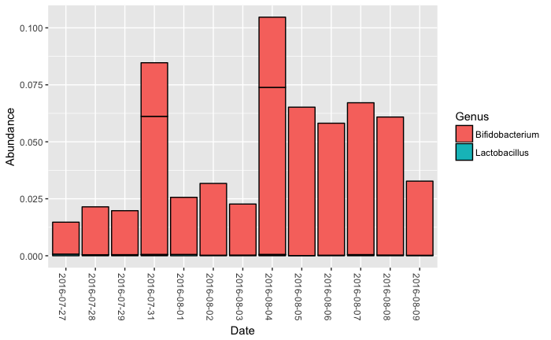

Now let’s cluster the samples

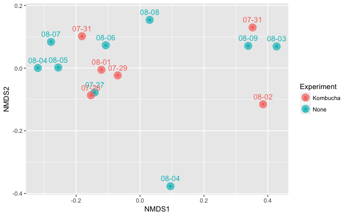

and try a heatmap, just looking at the top 20 taxa (in this case at the genus rank);

[output not shown]

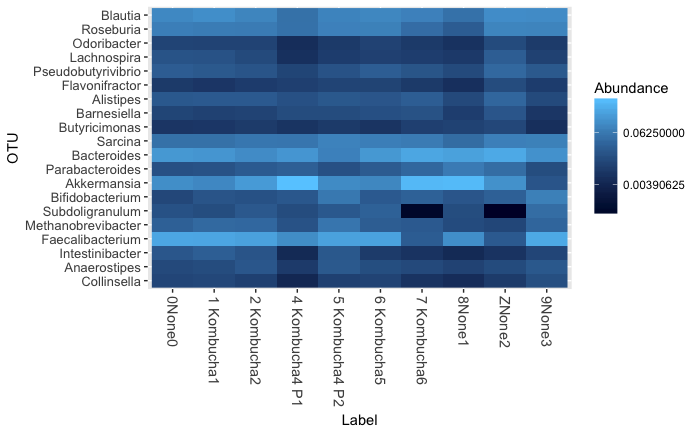

# Diversity

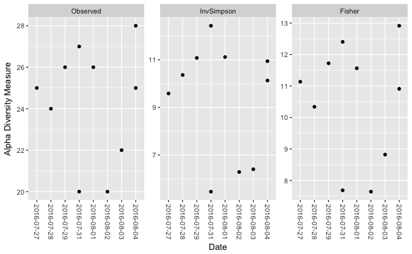

# Species Level Analysis

uBiome’s 16S technology only looks at the V4 subunit, with less than 300 reads in each direction. That’s plenty for most genus and above analysis, but it gets strained at the species level. Still, some of the species *are* visible, so let’s look at the most common ones:

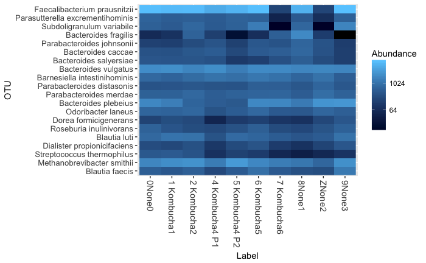

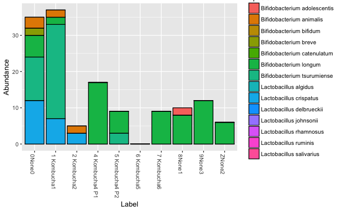

Note that because this is species level, this figure differs from genus one above because not every species within the genus is identifiable.